# Project Description

### Examining the relationship between Product (Treadmill Model) and Fitness level in light of customer Gender, Educational Level, Marital Status, and Age Group

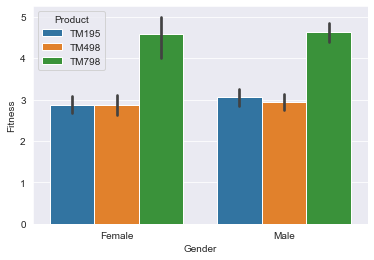

```python
sns.barplot(df.Gender, df.Fitness, hue=df.Product);
```

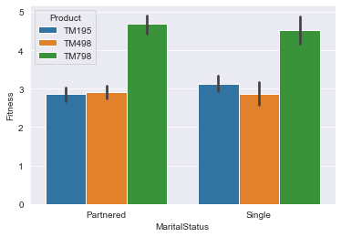

```python
sns.barplot(df.MaritalStatus, df.Fitness, hue=df.Product);
```

```
College            85
Some_college       65
Graduate_School    27
High_School         3
Name: Education_Level, dtype: int64
```

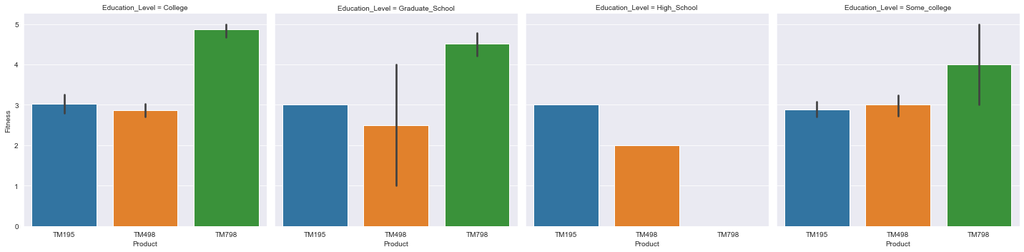

```python
sns.catplot(x='Product', y='Fitness',
             col='Education_Level',
             data=df,
             col_wrap=4,
             kind="bar");
df.Education_Level.value_counts()
```

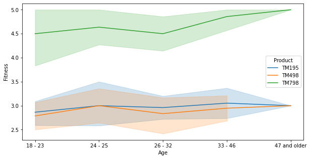

```python
plt.figure(figsize=(10,5))
sns.lineplot(x="Age_groups", y="Fitness", ci=95, data=df, hue='Product')
plt.ylabel('Fitness')
plt.xlabel('Age')
plt.show()
```

**Observations**

- TM195 and TM498 customer groups are more similar in contrast to TM798 customers in terms of Fitness ratings, even when considering gender, marital status education level, and age
- With only 3 customer counts, it is difficult to draw any conclusions on the relationship between Treadmill/Product model and Fitness for customers with a High School education level

### Examining the relationship between Product (Treadmill Model) and Income level in light of customer Gender, Educational Level, Marital Status, and Age Group

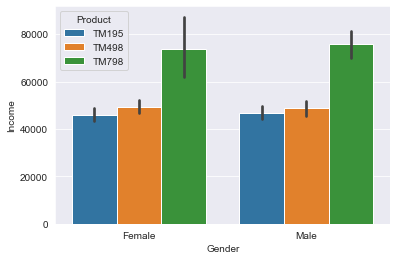

```python
sns.barplot(df.Gender, df.Income, hue=df.Product);
```

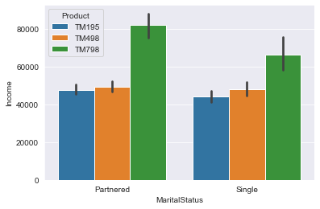

```python
sns.barplot(df.MaritalStatus, df.Income, hue=df.Product);
```

```
College            85
Some_college       65
Graduate_School    27
High_School         3
Name: Education_Level, dtype: int64
```

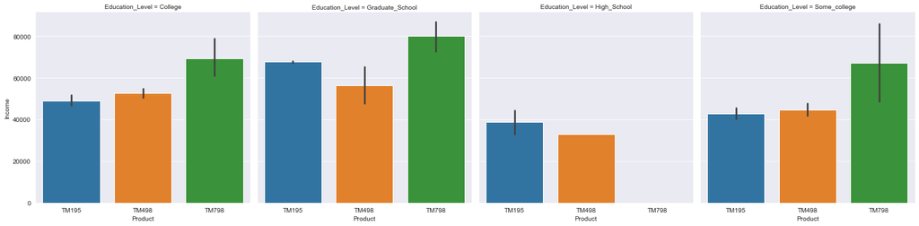

```python
sns.catplot(x='Product', y='Income',
             col='Education_Level',
             data=df,
             col_wrap=4,
             kind="bar");
df.Education_Level.value_counts()
```

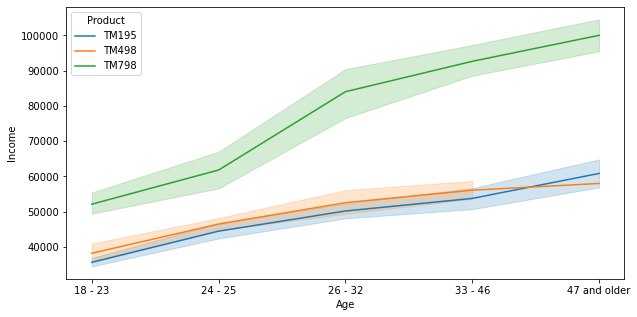

```python
plt.figure(figsize=(10,5))
sns.lineplot(x="Age_groups", y="Income", ci=95, data=df, hue='Product')
plt.ylabel('Income')
plt.xlabel('Age')
plt.show()
```

**Observations**

- TM798 customers who have a partner make higher income than single TM798 customers though both groups have higher income on average than TM195 and TM498 customers
- TM195 and TM498 customer groups are more similar in contrast to TM798 customers in terms of Income, even when considering gender, marital status education level, and age
- With only 3 customer counts, it is difficult to draw any conclusions on the relationship between Treadmill/Product model and Income for customers with a High School education level

### Examining the relationship between Product (Treadmill Model) and Miles expected to run in light of customer Gender, Educational Level, Marital Status, and Age Group

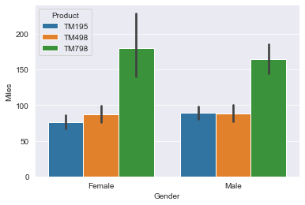

```python
sns.barplot(df.Gender, df.Miles, hue=df.Product);
```

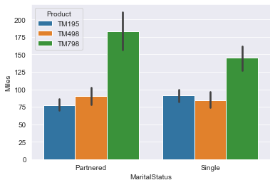

```python
sns.barplot(df.MaritalStatus, df.Miles, hue=df.Product);
```

```
College            85
Some_college       65
Graduate_School    27
High_School         3
Name: Education_Level, dtype: int64
```

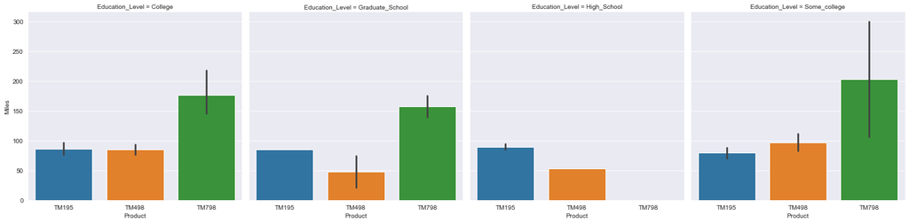

```python
sns.catplot(x='Product', y='Miles',
             col='Education_Level',
             data=df,
             col_wrap=4,
             kind="bar");
df.Education_Level.value_counts()
```

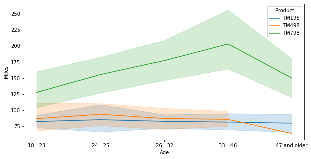

```python
plt.figure(figsize=(10,5))
sns.lineplot(x="Age_groups", y="Miles", ci=95, data=df, hue='Product')
plt.ylabel('Miles')
plt.xlabel('Age')
plt.show()
```

**Observations**

- TM195 and TM498 customer groups are more similar in contrast to TM798 customers in terms of Miles expected to run, even when considering gender, marital status education level, and age
- TM798 customers who have a partner expect to run more miles than single TM798 customers though both groups have higher Miles ratings on average than TM195 and TM498 customers
- We observe a decline in expected miles run among older TM798 and TM498 customers
- With only 3 customer counts, it is difficult to draw any conclusions on the relationship between Treadmill/Product model and Miles for customers with a High School education level

### Examining the relationship between Product (Treadmill Model) and Age in light of customer Gender, Educational Level, and Marital Status

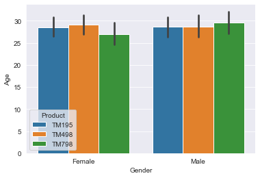

```python
sns.barplot(df.Gender, df.Age, hue=df.Product);
```

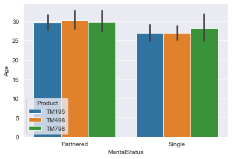

```python
sns.barplot(df.MaritalStatus, df.Age, hue=df.Product);
```

```
College            85
Some_college       65
Graduate_School    27
High_School         3
Name: Education_Level, dtype: int64
```

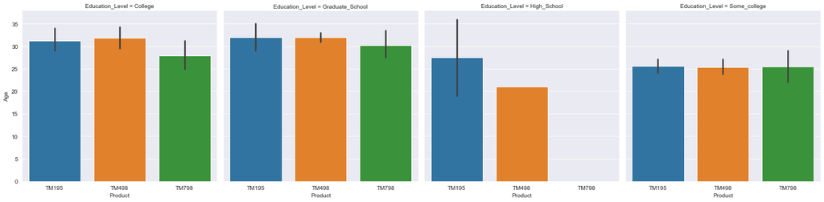

```python
sns.catplot(x='Product', y='Age',
             col='Education_Level',
             data=df,
             col_wrap=4,
             kind="bar");
df.Education_Level.value_counts()
```

**Observations**

- Customers across the three treadmill models are similar in age regardless of gender, marital status and education: all group age ranges falling between mid 20s to mid 30s.
- Males in TM798 group tend to be slightly older than female customers in that product group
- Customers with a partner tend to be slightly older than customers who are single
- Average age of customers with some college look to be younger than other education level groups (excluding customers in the High School group, a group too small to draw meaningful conclusions from)
- With only 3 customer counts, it is difficult to draw any conclusions on the relationship between Treadmill/Product model and Age for customers with a High School education level

## Conclusion

We have synthesized key findings below into customer profiles for each of the three treadmills sold at Cardio Good Fitness: TM195, TM498, and TM798

### Customer Profiles

TM195

- The typical TM195 customer is in their mid 20s to mid 30s, more likely to be in a relationship than single, college-educated and with an yearly income of about $46,000
- The typical user is also moderately fit and expects to use the treadmill 3 to 4 days a week to run about 80 miles

TM498

- The typical TM498 customer is in their mid 20s to mid 40s, more likely to be in a relationship than single, college-educated and with an yearly income of about $49,000
- The typical user is also moderately fit and expects to use the treadmill on average 3 days a week to run about 87 miles

TM798

- The typical TM798 customer is male, in their mid 20s to mid 30s, more likely to be in a relationship than single, more likely to have a graduate degree and with an yearly income of about $75,000
- The typical user is also very fit and expects heavy use out of the treadmill: 4 to 5 days a week to run about 167 miles

### Recommendations based on analysis insights

- Based on our findings, it seems that a more differentiated branding strategy is needed for the TM195 and TM498 treadmill models as currently we observe much overlap between these customer groups
- For the TM195 model we recommend targeting customers who are recent college grads/young professionals with yearly income in the $40,000 to $50,000 range (therefore more price-sensitive) and interested in maintaining or incorporating moderate to high levels of weekly exercise
- TM498 seems to attract a customer base that is slightly older than TM195 and TM798 customers. A recommendation for this treadmill model would be to target individuals in their late 30s to mid 40s with yearly income around $50,000 to $60,000 who desire to keep or incorporate moderate levels of weekly exercise in their lives
- TM798 customers are established young professionals, high income-earning, highly motivated runners. They seem to follow the mantra “work hard, play hard”. We recommend a branding strategy that plays to these customer characteristics in order to continue to resonate with them and expand the brand’s reach among this target audience

```python
import pandas_profiling
```

```python
#Getting the pandas profiling report for original dataset
pandas_profiling.ProfileReport(data)
```

[interactive chart not shown]